# R for EPP research Assignment 3

Angelos-Miltiadis Krypotos

2016-03-16

## How to complete the assignment.

Please write your answers below each question, indicating clearly to which question (or subquestion) your answer refers to. I would prefer if you would send your answers as an html document using “knitr” and with all the code having been already executed. You can create html documents in R studio by just clicking the notepad icon on the top – For more info how to create notebooks in R studio see [here](https://support.rstudio.com/hc/en-us/articles/200552276-Creating-Notebooks-from-R-Scripts). If you want, you can also send your answers as an .R script. Lastly, writing your assignments in .doc or .docx is also OK, but because of automatised formatting etc., it would be hard for me to check whether the code is running properly or not.

## Goals of the assignment

- Gain experience in statistical analyses using R

## Exercise 1

Check the links below for refreshing what we did in class (+ the slides of course):

- [t-tests](http://www.statmethods.net/stats/ttest.html)
- [Correlations](http://www.statmethods.net/stats/correlations.html)
- [The BayesFactor packages](http://bayesfactorpcl.r-forge.r-project.org/). A nice page for learning how to do Bayesian analysis with the BayesFactor package.

## Exercise 2

Run the code below.

```r
set.seed(100)
depression <- sample(10:40, 100, replace = TRUE)
sex <- c("Men", "Women")
df <- data.frame(depression, sex)
```

Check whether there are sex differences in terms of depression. Do that within: a) a frequentists framework, and b) a Bayesian framework (by using the BayesFactor package). c) Does depression differ from 0? d) For 2b, report the Bayes factor after changing the r scale parameter to the values, .707, 1, and 2.

## Answer 2a

```r
t.test(depression~sex, data = df)
```

```
##
##  Welch Two Sample t-test
##
## data:  depression by sex
## t = 0.11037, df = 96.738, p-value = 0.9123
## alternative hypothesis: true difference in means is not equal to 0
## 95 percent confidence interval:
##  -3.056972  3.416972
## sample estimates:
##   mean in group Men mean in group Women
##               25.72               25.54
```

## Answer 2b

```r
library(BayesFactor)
ttestBF(df$depression[df$sex == "Men"], df$depression[df$sex == "Women"])
```

```
## Bayes factor analysis
## --------------
## [1] Alt., r=0.707 : 0.211953 ±0.03%
##
## Against denominator:
##   Null, mu1-mu2 = 0
## ---
## Bayes factor type: BFindepSample, JZS
```

## Answer 2c

```r
t.test(df$depression, mu = 0)
```

```
##
##  One Sample t-test
##
## data:  df$depression
## t = 31.589, df = 99, p-value < 2.2e-16
## alternative hypothesis: true mean is not equal to 0
## 95 percent confidence interval:
##  24.02007 27.23993
## sample estimates:
## mean of x
##     25.63
```

Yes.

## Answer 2d

```r
for (i in c(.707, 1, 2)){
  print(extractBF(ttestBF(df$depression[df$sex == "Men"], df$depression[df$sex == "Women"], rscale = i)))
}
```

```
##                      bf        error                     time         code
## Alt., r=0.707 0.2119812 0.0002881295 Wed Mar 16 16:16:22 2016 1d8070b05f1c
##                  bf       error                     time         code
## Alt., r=1 0.1547238 0.000743678 Wed Mar 16 16:16:22 2016 1d803fd43f8e
##                   bf        error                     time         code
## Alt., r=2 0.07949169 5.154581e-06 Wed Mar 16 16:16:22 2016 1d801b2f514d
```

OR – But this is more advanced

```r
sapply(c(.707, 1, 2), function(x) ttestBF(df$depression[df$sex == "Men"], df$depression[df$sex == "Women"], rscale = x))
```

```
## [[1]]
## Bayes factor analysis
## --------------
## [1] Alt., r=0.707 : 0.2119812 ±0.03%
##
## Against denominator:
##   Null, mu1-mu2 = 0
## ---
## Bayes factor type: BFindepSample, JZS
##
##
## [[2]]
## Bayes factor analysis
## --------------
## [1] Alt., r=1 : 0.1547238 ±0.07%
##
## Against denominator:
##   Null, mu1-mu2 = 0
## ---
## Bayes factor type: BFindepSample, JZS
##
##
## [[3]]
## Bayes factor analysis
## --------------
## [1] Alt., r=2 : 0.07949169 ±0%
##
## Against denominator:
##   Null, mu1-mu2 = 0
## ---
## Bayes factor type: BFindepSample, JZS
```

## Exercise 3

Run the code below

```r
ID <- as.factor(rep(1:100, each = 4))
CS <- as.factor(c("+", "-"))
Trial <- as.factor(c(1, 1, 2, 2))
group <- as.factor(c("exp", "exp", "exp", "exp", "ctl", "ctl", "ctl", "ctl"))
RT <- rnorm(100, 5, 4)
df <- data.frame(ID, CS, Trial, group, RT)
```

1. Run a repeated measures ANOVA in which you include CS and Trial as within-subject factor. Include *no* between-subject factors.
2. Do the same using Bayes factors
3. Make a boxplot of RTs for each group

## Answer 3a

```r
library(ez)
ezANOVA(df, dv = "RT", wid = ID, within = .("Trial", "CS"), type = 3)
```

```
## $ANOVA
##     Effect DFn DFd         F          p p<.05          ges
## 2    Trial   1  99 0.1475063 0.70175358       0.0004793287
## 3       CS   1  99 8.1151414 0.00533973     * 0.0260964744
## 4 Trial:CS   1  99 1.3464109 0.24869710       0.0029525779
```

## Answer 3b

NOTE: I put 100 iterations because it was taking too long. It is better to have > 10000 iterations when you run your analyses!

```r
anovaBF(RT~CS*Trial + ID, data = df, iterations = 100, progress = FALSE)
```

```
## Bayes factor analysis
## --------------
## [1] ID                                                           : 0.001068967  ±0%
## [2] CS                                                           : 17.76682     ±0%
## [3] ID + CS                                                      : 0.0242952    ±11.25%
## [4] ID + CS + ID:CS                                              : 0.1640898    ±6.69%
## [5] Trial                                                        : 0.1210696    ±0%
## [6] ID + Trial                                                   : 0.0001735844 ±15.86%
## [7] CS + Trial                                                   : 1.952427     ±8.88%
## [8] ID + CS + Trial                                              : 0.00209445   ±4.57%
## [9] ID + CS + ID:CS + Trial                                      : 0.0168759    ±9.76%
## [10] ID + Trial + ID:Trial                                       : 0.0004374982 ±16.21%
## [11] ID + CS + Trial + ID:Trial                                  : 0.01508875   ±8.62%
## [12] ID + CS + ID:CS + Trial + ID:Trial                          : 6.379211     ±13.66%
## [13] CS + Trial + CS:Trial                                       : 0.4606261    ±8.91%
## [14] ID + CS + Trial + CS:Trial                                  : 0.0004745403 ±7.44%
## [15] ID + CS + ID:CS + Trial + CS:Trial                          : 0.005143438  ±11.73%
## [16] ID + CS + Trial + ID:Trial + CS:Trial                       : 0.002653527  ±7.77%
## [17] ID + CS + ID:CS + Trial + ID:Trial + CS:Trial               : 4.248521     ±55.44%
## [18] ID + CS + ID:CS + Trial + ID:Trial + CS:Trial + ID:CS:Trial : 65.37641     ±25.03%
##
## Against denominator:
##   Intercept only
## ---
## Bayes factor type: BFlinearModel, JZS
```

## Answer 3c

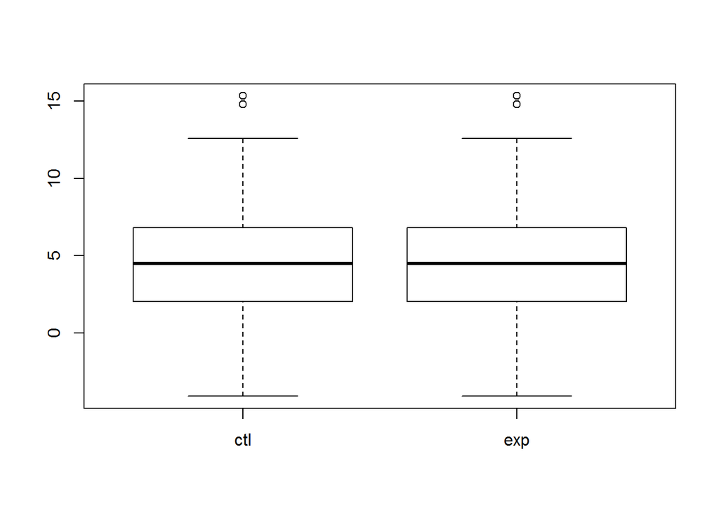

```r
boxplot(df$RT~df$group)
```

OR in separate plots

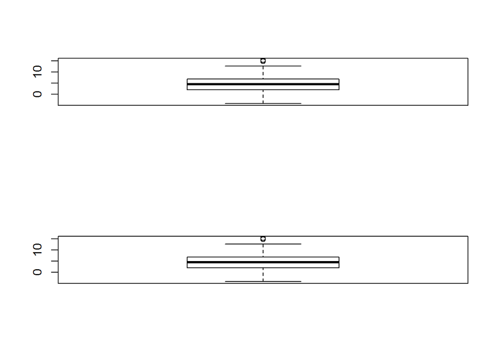

```r
layout(1:2)
tapply(df$RT, df$group, boxplot)
```